# Project 2: Investigating the dataset on The Movie Database (TMDb)

from Bastian Boegel Submitted in June 2020

# Introduction

I chose to analyse the movie database as the mvie industry is gaining more and more importance and revenue. The increasing success of movie streaming platforms like netflix and Disney plus confirm the importance and demand of the movie production. Besides, I am personally a big fan of movies.

With my data analysis I am aiming to identify the relationship between variables such as revenues, budget, genres and popularity. In particular, I want to analyse potential predictors for the movies success in terms of a) revenue, b) profit or c) popularity. Potential predictors include the budget, the genre and the main actor. Question 1: Does the budget, the main actor or the genre of a movie predict a movie's success?

As a second part of the analysis, I want to analyse which genres are most popular and how did this change in the years that are covered in this dataset. Question 2: Which genres have been the most popular during the years?

One assumption I have to make is that the given revenue and budget for each movie is in the same currency (USD). There was no explanation provided on kaggle.com.

# Data wrangling

Loading and importing data:

```python
# import and load data
import pandas as pd
import numpy as np
import matplotlib.pyplot as plt
import seaborn as sns
df = pd.read_csv('tmdb-movies.csv')
```

Gathering, assessing and cleaning data:

I will assess the structure of the dataset, check for errors, or missing values. Further, I will remove information and data that will not be used as well as duplicate information. I am aiming to get a clean datset for the data exploration step.

```python
#Assessing data
#Getting a first overview
df.head()
```

|  | id | imdb_id | popularity | budget | revenue | original_title | cast | homepage | director | tagline | ... | overview | runtime | genres | production_companies | release_date | vote_count | vote_average | release_year | budget_adj | revenue_adj |
| --- | --- | --- | --- | --- | --- | --- | --- | --- | --- | --- | --- | --- | --- | --- | --- | --- | --- | --- | --- | --- | --- |
| 0 | 135397 | tt0369610 | 32.985763 | 150000000 | 1513528810 | Jurassic World | Chris Pratt\|Bryce Dallas Howard\|Irrfan Khan\|Vi... | http://www.jurassicworld.com/ | Colin Trevorrow | The park is open. | ... | Twenty-two years after the events of Jurassic ... | 124 | Action\|Adventure\|Science Fiction\|Thriller | Universal Studios\|Amblin Entertainment\|Legenda... | 6/9/15 | 5562 | 6.5 | 2015 | 1.379999e+08 | 1.392446e+09 |
| 1 | 76341 | tt1392190 | 28.419936 | 150000000 | 378436354 | Mad Max: Fury Road | Tom Hardy\|Charlize Theron\|Hugh Keays-Byrne\|Nic... | http://www.madmaxmovie.com/ | George Miller | What a Lovely Day. | ... | An apocalyptic story set in the furthest reach... | 120 | Action\|Adventure\|Science Fiction\|Thriller | Village Roadshow Pictures\|Kennedy Miller Produ... | 5/13/15 | 6185 | 7.1 | 2015 | 1.379999e+08 | 3.481613e+08 |
| 2 | 262500 | tt2908446 | 13.112507 | 110000000 | 295238201 | Insurgent | Shailene Woodley\|Theo James\|Kate Winslet\|Ansel... | http://www.thedivergentseries.movie/#insurgent | Robert Schwentke | One Choice Can Destroy You | ... | Beatrice Prior must confront her inner demons ... | 119 | Adventure\|Science Fiction\|Thriller | Summit Entertainment\|Mandeville Films\|Red Wago... | 3/18/15 | 2480 | 6.3 | 2015 | 1.012000e+08 | 2.716190e+08 |
| 3 | 140607 | tt2488496 | 11.173104 | 200000000 | 2068178225 | Star Wars: The Force Awakens | Harrison Ford\|Mark Hamill\|Carrie Fisher\|Adam D... | http://www.starwars.com/films/star-wars-episod... | J.J. Abrams | Every generation has a story. | ... | Thirty years after defeating the Galactic Empi... | 136 | Action\|Adventure\|Science Fiction\|Fantasy | Lucasfilm\|Truenorth Productions\|Bad Robot | 12/15/15 | 5292 | 7.5 | 2015 | 1.839999e+08 | 1.902723e+09 |
| 4 | 168259 | tt2820852 | 9.335014 | 190000000 | 1506249360 | Furious 7 | Vin Diesel\|Paul Walker\|Jason Statham\|Michelle ... | http://www.furious7.com/ | James Wan | Vengeance Hits Home | ... | Deckard Shaw seeks revenge against Dominic Tor... | 137 | Action\|Crime\|Thriller | Universal Pictures\|Original Film\|Media Rights ... | 4/1/15 | 2947 | 7.3 | 2015 | 1.747999e+08 | 1.385749e+09 |

5 rows × 21 columns

Revenue and budget are given for the movies, however, no profit. I will calculate and add the profit as variable.

```python
#Inspecting the dataset including datatypes and check for missing values
df.info()
```

```
<class 'pandas.core.frame.DataFrame'>
RangeIndex: 10866 entries, 0 to 10865
Data columns (total 21 columns):
 #   Column                Non-Null Count  Dtype
---  ------                --------------  -----
 0   id                    10866 non-null  int64
 1   imdb_id               10856 non-null  object
 2   popularity            10866 non-null  float64
 3   budget                10866 non-null  int64
 4   revenue               10866 non-null  int64
 5   original_title        10866 non-null  object
 6   cast                  10790 non-null  object
 7   homepage              2936 non-null   object
 8   director              10822 non-null  object
 9   tagline               8042 non-null   object
 10  keywords              9373 non-null   object
 11  overview              10862 non-null  object
 12  runtime               10866 non-null  int64
 13  genres                10843 non-null  object
 14  production_companies  9836 non-null   object
 15  release_date          10866 non-null  object
 16  vote_count            10866 non-null  int64
 17  vote_average          10866 non-null  float64
 18  release_year          10866 non-null  int64
 19  budget_adj            10866 non-null  float64
 20  revenue_adj           10866 non-null  float64
dtypes: float64(4), int64(6), object(11)
memory usage: 1.7+ MB
```

```python
# Assessing basic statistics for each column:
df.describe()
```

|  | id | popularity | budget | revenue | runtime | vote_count | vote_average | release_year | budget_adj | revenue_adj |
| --- | --- | --- | --- | --- | --- | --- | --- | --- | --- | --- |
| count | 10866.000000 | 10866.000000 | 1.086600e+04 | 1.086600e+04 | 10866.000000 | 10866.000000 | 10866.000000 | 10866.000000 | 1.086600e+04 | 1.086600e+04 |
| mean | 66064.177434 | 0.646441 | 1.462570e+07 | 3.982332e+07 | 102.070863 | 217.389748 | 5.974922 | 2001.322658 | 1.755104e+07 | 5.136436e+07 |
| std | 92130.136561 | 1.000185 | 3.091321e+07 | 1.170035e+08 | 31.381405 | 575.619058 | 0.935142 | 12.812941 | 3.430616e+07 | 1.446325e+08 |
| min | 5.000000 | 0.000065 | 0.000000e+00 | 0.000000e+00 | 0.000000 | 10.000000 | 1.500000 | 1960.000000 | 0.000000e+00 | 0.000000e+00 |
| 25% | 10596.250000 | 0.207583 | 0.000000e+00 | 0.000000e+00 | 90.000000 | 17.000000 | 5.400000 | 1995.000000 | 0.000000e+00 | 0.000000e+00 |
| 50% | 20669.000000 | 0.383856 | 0.000000e+00 | 0.000000e+00 | 99.000000 | 38.000000 | 6.000000 | 2006.000000 | 0.000000e+00 | 0.000000e+00 |
| 75% | 75610.000000 | 0.713817 | 1.500000e+07 | 2.400000e+07 | 111.000000 | 145.750000 | 6.600000 | 2011.000000 | 2.085325e+07 | 3.369710e+07 |
| max | 417859.000000 | 32.985763 | 4.250000e+08 | 2.781506e+09 | 900.000000 | 9767.000000 | 9.200000 | 2015.000000 | 4.250000e+08 | 2.827124e+09 |

Cleaning data:

- Removing data that is not needed like irrelevant columns (e.g. relaese date, homepage, etc.)
- Removing data that is double
- Adding the variable profit calculated as revenue - budget
- Preparing the variable genres as this will be further analyzed as independent variable later (values need to be splitted around the separator "I")
- Same holds for the variable main actor

```python
#Unnecessary columns can be dropped
df.drop(['homepage', 'tagline', 'overview', 'imdb_id', 'keywords', 'release_date'], axis=1, inplace=True)
df.head()
```

|  | id | popularity | budget | revenue | original_title | cast | director | runtime | genres | production_companies | vote_count | vote_average | release_year | budget_adj | revenue_adj |
| --- | --- | --- | --- | --- | --- | --- | --- | --- | --- | --- | --- | --- | --- | --- | --- |
| 0 | 135397 | 32.985763 | 150000000 | 1513528810 | Jurassic World | Chris Pratt\|Bryce Dallas Howard\|Irrfan Khan\|Vi... | Colin Trevorrow | 124 | Action\|Adventure\|Science Fiction\|Thriller | Universal Studios\|Amblin Entertainment\|Legenda... | 5562 | 6.5 | 2015 | 1.379999e+08 | 1.392446e+09 |
| 1 | 76341 | 28.419936 | 150000000 | 378436354 | Mad Max: Fury Road | Tom Hardy\|Charlize Theron\|Hugh Keays-Byrne\|Nic... | George Miller | 120 | Action\|Adventure\|Science Fiction\|Thriller | Village Roadshow Pictures\|Kennedy Miller Produ... | 6185 | 7.1 | 2015 | 1.379999e+08 | 3.481613e+08 |
| 2 | 262500 | 13.112507 | 110000000 | 295238201 | Insurgent | Shailene Woodley\|Theo James\|Kate Winslet\|Ansel... | Robert Schwentke | 119 | Adventure\|Science Fiction\|Thriller | Summit Entertainment\|Mandeville Films\|Red Wago... | 2480 | 6.3 | 2015 | 1.012000e+08 | 2.716190e+08 |
| 3 | 140607 | 11.173104 | 200000000 | 2068178225 | Star Wars: The Force Awakens | Harrison Ford\|Mark Hamill\|Carrie Fisher\|Adam D... | J.J. Abrams | 136 | Action\|Adventure\|Science Fiction\|Fantasy | Lucasfilm\|Truenorth Productions\|Bad Robot | 5292 | 7.5 | 2015 | 1.839999e+08 | 1.902723e+09 |
| 4 | 168259 | 9.335014 | 190000000 | 1506249360 | Furious 7 | Vin Diesel\|Paul Walker\|Jason Statham\|Michelle ... | James Wan | 137 | Action\|Crime\|Thriller | Universal Pictures\|Original Film\|Media Rights ... | 2947 | 7.3 | 2015 | 1.747999e+08 | 1.385749e+09 |

```python
#Removing data that is double
#1. Duplicate rows
sum(df.duplicated())
```

```
0
```

```python
#df.drop_duplicates(inplace=True)
#print(sum(df.duplicated()))
```

```python
#2. Missing values
df.isnull().sum()
```

```
id                         0
popularity                 0
budget                     0
revenue                    0
original_title             0
cast                      76
director                  44
runtime                    0
genres                    23
production_companies    1030
vote_count                 0
vote_average               0
release_year               0
budget_adj                 0
revenue_adj                0
dtype: int64
```

```python
#Critical variables do not have (many) missing avlues. I will remove rows with missing cast, production companies, etc...
df.dropna(inplace=True)
df.info()
```

```
<class 'pandas.core.frame.DataFrame'>
Int64Index: 9772 entries, 0 to 10865
Data columns (total 15 columns):
 #   Column                Non-Null Count  Dtype
---  ------                --------------  -----
 0   id                    9772 non-null   int64
 1   popularity            9772 non-null   float64
 2   budget                9772 non-null   int64
 3   revenue               9772 non-null   int64
 4   original_title        9772 non-null   object
 5   cast                  9772 non-null   object
 6   director              9772 non-null   object
 7   runtime               9772 non-null   int64
 8   genres                9772 non-null   object
 9   production_companies  9772 non-null   object
 10  vote_count            9772 non-null   int64
 11  vote_average          9772 non-null   float64
 12  release_year          9772 non-null   int64
 13  budget_adj            9772 non-null   float64
 14  revenue_adj           9772 non-null   float64
dtypes: float64(4), int64(6), object(5)
memory usage: 1.2+ MB
```

Additional cleaning checks:

- No renaming of columns needed (lower cases are used if applicable)
- The main dependent variables 'revenue' and 'budget' are integers, whicha allows for calculating the profit

```python
#Create new variable "profit"
df['profit'] = df['revenue'] - df['budget']
df.head()
```

|  | id | popularity | budget | revenue | original_title | cast | director | runtime | genres | production_companies | vote_count | vote_average | release_year | budget_adj | revenue_adj | profit |
| --- | --- | --- | --- | --- | --- | --- | --- | --- | --- | --- | --- | --- | --- | --- | --- | --- |
| 0 | 135397 | 32.985763 | 150000000 | 1513528810 | Jurassic World | Chris Pratt\|Bryce Dallas Howard\|Irrfan Khan\|Vi... | Colin Trevorrow | 124 | Action\|Adventure\|Science Fiction\|Thriller | Universal Studios\|Amblin Entertainment\|Legenda... | 5562 | 6.5 | 2015 | 1.379999e+08 | 1.392446e+09 | 1363528810 |
| 1 | 76341 | 28.419936 | 150000000 | 378436354 | Mad Max: Fury Road | Tom Hardy\|Charlize Theron\|Hugh Keays-Byrne\|Nic... | George Miller | 120 | Action\|Adventure\|Science Fiction\|Thriller | Village Roadshow Pictures\|Kennedy Miller Produ... | 6185 | 7.1 | 2015 | 1.379999e+08 | 3.481613e+08 | 228436354 |
| 2 | 262500 | 13.112507 | 110000000 | 295238201 | Insurgent | Shailene Woodley\|Theo James\|Kate Winslet\|Ansel... | Robert Schwentke | 119 | Adventure\|Science Fiction\|Thriller | Summit Entertainment\|Mandeville Films\|Red Wago... | 2480 | 6.3 | 2015 | 1.012000e+08 | 2.716190e+08 | 185238201 |
| 3 | 140607 | 11.173104 | 200000000 | 2068178225 | Star Wars: The Force Awakens | Harrison Ford\|Mark Hamill\|Carrie Fisher\|Adam D... | J.J. Abrams | 136 | Action\|Adventure\|Science Fiction\|Fantasy | Lucasfilm\|Truenorth Productions\|Bad Robot | 5292 | 7.5 | 2015 | 1.839999e+08 | 1.902723e+09 | 1868178225 |
| 4 | 168259 | 9.335014 | 190000000 | 1506249360 | Furious 7 | Vin Diesel\|Paul Walker\|Jason Statham\|Michelle ... | James Wan | 137 | Action\|Crime\|Thriller | Universal Pictures\|Original Film\|Media Rights ... | 2947 | 7.3 | 2015 | 1.747999e+08 | 1.385749e+09 | 1316249360 |

```python
#Check: There is no negative number for profit:
df.profit.describe()
```

```
count    9.772000e+03
mean     2.805154e+07
std      1.014445e+08
min     -4.139124e+08
25%      0.000000e+00
50%      0.000000e+00
75%      1.420195e+07
max      2.544506e+09
Name: profit, dtype: float64
```

```python
df.loc[df['profit'] < 0, 'profit'] = 0
```

```python
df.profit.describe()
```

```
count    9.772000e+03
mean     3.112680e+07
std      9.995743e+07
min      0.000000e+00
25%      0.000000e+00
50%      0.000000e+00
75%      1.420195e+07
max      2.544506e+09
Name: profit, dtype: float64
```

```python
df.release_year.describe()
```

```
count    9772.000000
mean     2000.878428
std        13.036794
min      1960.000000
25%      1994.000000
50%      2005.000000
75%      2011.000000
max      2015.000000
Name: release_year, dtype: float64
```

```python
#I'll allocate the release years into groups for decades for a better analysis of the change over year:
bin_edges = [1960, 1970, 1980, 1990, 2000, 2010, 2015]
bin_names = ['60s', '70s', '80s', '90s', '2000s', '2010s']
df['decades'] = pd.cut(df['release_year'], bin_edges, labels=bin_names)
df.head()
```

|  | id | popularity | budget | revenue | original_title | cast | director | runtime | genres | production_companies | vote_count | vote_average | release_year | budget_adj | revenue_adj | profit | decades |
| --- | --- | --- | --- | --- | --- | --- | --- | --- | --- | --- | --- | --- | --- | --- | --- | --- | --- |
| 0 | 135397 | 32.985763 | 150000000 | 1513528810 | Jurassic World | Chris Pratt\|Bryce Dallas Howard\|Irrfan Khan\|Vi... | Colin Trevorrow | 124 | Action\|Adventure\|Science Fiction\|Thriller | Universal Studios\|Amblin Entertainment\|Legenda... | 5562 | 6.5 | 2015 | 1.379999e+08 | 1.392446e+09 | 1363528810 | 2010s |
| 1 | 76341 | 28.419936 | 150000000 | 378436354 | Mad Max: Fury Road | Tom Hardy\|Charlize Theron\|Hugh Keays-Byrne\|Nic... | George Miller | 120 | Action\|Adventure\|Science Fiction\|Thriller | Village Roadshow Pictures\|Kennedy Miller Produ... | 6185 | 7.1 | 2015 | 1.379999e+08 | 3.481613e+08 | 228436354 | 2010s |
| 2 | 262500 | 13.112507 | 110000000 | 295238201 | Insurgent | Shailene Woodley\|Theo James\|Kate Winslet\|Ansel... | Robert Schwentke | 119 | Adventure\|Science Fiction\|Thriller | Summit Entertainment\|Mandeville Films\|Red Wago... | 2480 | 6.3 | 2015 | 1.012000e+08 | 2.716190e+08 | 185238201 | 2010s |
| 3 | 140607 | 11.173104 | 200000000 | 2068178225 | Star Wars: The Force Awakens | Harrison Ford\|Mark Hamill\|Carrie Fisher\|Adam D... | J.J. Abrams | 136 | Action\|Adventure\|Science Fiction\|Fantasy | Lucasfilm\|Truenorth Productions\|Bad Robot | 5292 | 7.5 | 2015 | 1.839999e+08 | 1.902723e+09 | 1868178225 | 2010s |
| 4 | 168259 | 9.335014 | 190000000 | 1506249360 | Furious 7 | Vin Diesel\|Paul Walker\|Jason Statham\|Michelle ... | James Wan | 137 | Action\|Crime\|Thriller | Universal Pictures\|Original Film\|Media Rights ... | 2947 | 7.3 | 2015 | 1.747999e+08 | 1.385749e+09 | 1316249360 | 2010s |

Please note, I found this code in the udacity chatroom posted by one of the students. https://hub.udacity.com/rooms/community:nd002:843718-project-107-smg-2?contextType=room

```python
#Preparing the variable genres (values need to be splitted around the separator "I")
df_genres = df['genres'].str.split('|', expand=True)
df_genres.head()
```

|  | 0 | 1 | 2 | 3 | 4 |
| --- | --- | --- | --- | --- | --- |
| 0 | Action | Adventure | Science Fiction | Thriller | None |
| 1 | Action | Adventure | Science Fiction | Thriller | None |
| 2 | Adventure | Science Fiction | Thriller | None | None |
| 3 | Action | Adventure | Science Fiction | Fantasy | None |
| 4 | Action | Crime | Thriller | None | None |

```python
#Extending the dataset by splitted genre values to show genres separately
df[['genre1','genre2','genre3','genre4','genre5']] = df['genres'].str.split('|', expand=True)
df.head()
```

[output not shown]

```python
#Check:
df['genre1'].unique()
```

```
array(['Action', 'Adventure', 'Western', 'Science Fiction', 'Drama',
       'Family', 'Comedy', 'Crime', 'Romance', 'War', 'Mystery',
       'Thriller', 'Fantasy', 'History', 'Animation', 'Horror', 'Music',
       'Documentary', 'TV Movie', 'Foreign'], dtype=object)
```

```python
#Preparing the variable main actors (values for cast need to be splitted around the separator "I")
df_actors = df['cast'].str.split('|', expand=True)
df_actors.head()
```

|  | 0 | 1 | 2 | 3 | 4 |
| --- | --- | --- | --- | --- | --- |
| 0 | Chris Pratt | Bryce Dallas Howard | Irrfan Khan | Vincent D'Onofrio | Nick Robinson |
| 1 | Tom Hardy | Charlize Theron | Hugh Keays-Byrne | Nicholas Hoult | Josh Helman |
| 2 | Shailene Woodley | Theo James | Kate Winslet | Ansel Elgort | Miles Teller |
| 3 | Harrison Ford | Mark Hamill | Carrie Fisher | Adam Driver | Daisy Ridley |
| 4 | Vin Diesel | Paul Walker | Jason Statham | Michelle Rodriguez | Dwayne Johnson |

```python
#Extending the dataset by splitted cast values to show actors separately
df[['actor1','actor2','actor3','actor4','actor5']] = df['cast'].str.split('|', expand=True)
df.head()
```

|  | id | popularity | budget | revenue | original_title | cast | director | runtime | genres | production_companies | ... | genre1 | genre2 | genre3 | genre4 | genre5 | actor1 | actor2 | actor3 | actor4 | actor5 |
| --- | --- | --- | --- | --- | --- | --- | --- | --- | --- | --- | --- | --- | --- | --- | --- | --- | --- | --- | --- | --- | --- |
| 0 | 135397 | 32.985763 | 150000000 | 1513528810 | Jurassic World | Chris Pratt\|Bryce Dallas Howard\|Irrfan Khan\|Vi... | Colin Trevorrow | 124 | Action\|Adventure\|Science Fiction\|Thriller | Universal Studios\|Amblin Entertainment\|Legenda... | ... | Action | Adventure | Science Fiction | Thriller | None | Chris Pratt | Bryce Dallas Howard | Irrfan Khan | Vincent D'Onofrio | Nick Robinson |
| 1 | 76341 | 28.419936 | 150000000 | 378436354 | Mad Max: Fury Road | Tom Hardy\|Charlize Theron\|Hugh Keays-Byrne\|Nic... | George Miller | 120 | Action\|Adventure\|Science Fiction\|Thriller | Village Roadshow Pictures\|Kennedy Miller Produ... | ... | Action | Adventure | Science Fiction | Thriller | None | Tom Hardy | Charlize Theron | Hugh Keays-Byrne | Nicholas Hoult | Josh Helman |
| 2 | 262500 | 13.112507 | 110000000 | 295238201 | Insurgent | Shailene Woodley\|Theo James\|Kate Winslet\|Ansel... | Robert Schwentke | 119 | Adventure\|Science Fiction\|Thriller | Summit Entertainment\|Mandeville Films\|Red Wago... | ... | Adventure | Science Fiction | Thriller | None | None | Shailene Woodley | Theo James | Kate Winslet | Ansel Elgort | Miles Teller |
| 3 | 140607 | 11.173104 | 200000000 | 2068178225 | Star Wars: The Force Awakens | Harrison Ford\|Mark Hamill\|Carrie Fisher\|Adam D... | J.J. Abrams | 136 | Action\|Adventure\|Science Fiction\|Fantasy | Lucasfilm\|Truenorth Productions\|Bad Robot | ... | Action | Adventure | Science Fiction | Fantasy | None | Harrison Ford | Mark Hamill | Carrie Fisher | Adam Driver | Daisy Ridley |
| 4 | 168259 | 9.335014 | 190000000 | 1506249360 | Furious 7 | Vin Diesel\|Paul Walker\|Jason Statham\|Michelle ... | James Wan | 137 | Action\|Crime\|Thriller | Universal Pictures\|Original Film\|Media Rights ... | ... | Action | Crime | Thriller | None | None | Vin Diesel | Paul Walker | Jason Statham | Michelle Rodriguez | Dwayne Johnson |

5 rows × 27 columns

```python
#Check:
df['actor1'].unique()
```

```
array(['Chris Pratt', 'Tom Hardy', 'Shailene Woodley', ...,
       'Innokentiy Smoktunovskiy', 'Tatsuya Mihashi', 'Harold P. Warren'],
      dtype=object)
```

```python
#Inspecting the dataset again
df.info()
```

```
<class 'pandas.core.frame.DataFrame'>
Int64Index: 9772 entries, 0 to 10865
Data columns (total 27 columns):
 #   Column                Non-Null Count  Dtype
---  ------                --------------  -----
 0   id                    9772 non-null   int64
 1   popularity            9772 non-null   float64
 2   budget                9772 non-null   int64
 3   revenue               9772 non-null   int64
 4   original_title        9772 non-null   object
 5   cast                  9772 non-null   object
 6   director              9772 non-null   object
 7   runtime               9772 non-null   int64
 8   genres                9772 non-null   object
 9   production_companies  9772 non-null   object
```

[output cut: 19 more lines]

The data looks clean and ready to be further analysed.

# Exploratory Data Analysis

General exploratory analysis

[figure not shown]

```python
#Assessing numerical data:
df.hist(figsize=(10, 10));
```

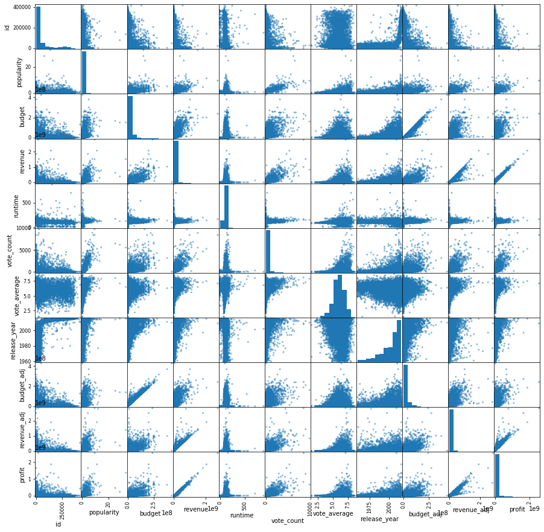

```python
pd.plotting.scatter_matrix(df, figsize=(15, 15));
```

Question 1: Does the budget, the main actor or the genre of a movie predict a movie's success?

The first variable to be looked at is the budget. A scatterplot can be created in order to detect a potential correlation between a movie's budget and its revenue, its profit or its popularity.

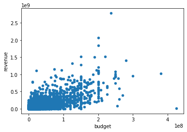

```python
# plot relationship between budget and revenue
df.plot(x = 'budget', y = 'revenue', kind ='scatter')
```

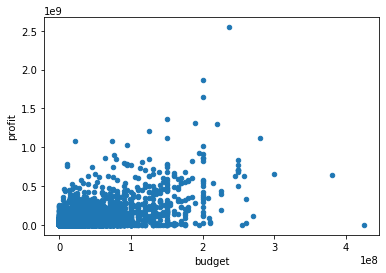

```python
# plot relationship between budget and revenue
df.plot(x = 'budget', y = 'profit', kind ='scatter')
```

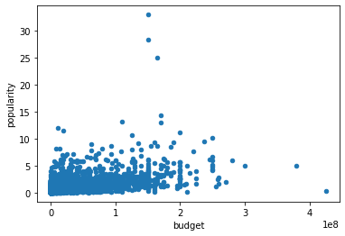

```python
# plot relationship between budget and revenue
df.plot(x = 'budget', y = 'popularity', kind ='scatter')
```

The second variable to be looked at is the main actor. Which (main) actors are associated with movies with the highest revenues?

```python
#Dataset is to be analysed within the top 100 movies based on revenue:
df_top_100_movies = df.sort_values(by=['revenue'], ascending=False).head(100)
df_top_100_movies['original_title'].nunique()
```

```
100
```

```python
df_top_100_movies.describe()
```

|  | id | popularity | budget | revenue | runtime | vote_count | vote_average | release_year | budget_adj | revenue_adj | profit |
| --- | --- | --- | --- | --- | --- | --- | --- | --- | --- | --- | --- |
| count | 100.000000 | 100.000000 | 1.000000e+02 | 1.000000e+02 | 100.000000 | 100.000000 | 100.000000 | 100.000000 | 1.000000e+02 | 1.000000e+02 | 1.000000e+02 |
| mean | 43314.780000 | 5.191795 | 1.542350e+08 | 8.979584e+08 | 130.070000 | 3475.060000 | 6.909000 | 2007.970000 | 1.570108e+08 | 9.654023e+08 | 7.437234e+08 |
| std | 55833.708222 | 4.467371 | 6.694002e+07 | 3.189943e+08 | 25.168625 | 1839.603382 | 0.651199 | 6.817172 | 6.237636e+07 | 4.034864e+08 | 3.069387e+08 |
| min | 11.000000 | 0.436803 | 1.050000e+07 | 6.118994e+08 | 88.000000 | 201.000000 | 5.600000 | 1977.000000 | 2.372625e+07 | 5.726906e+08 | 3.990268e+08 |
| 25% | 673.750000 | 2.755044 | 1.122500e+08 | 7.097980e+08 | 110.250000 | 2245.750000 | 6.400000 | 2004.750000 | 1.149844e+08 | 7.086393e+08 | 5.694419e+08 |
| 50% | 12299.500000 | 4.264860 | 1.500000e+08 | 8.079637e+08 | 132.000000 | 3169.500000 | 6.950000 | 2010.000000 | 1.565855e+08 | 8.776267e+08 | 6.604137e+08 |
| 75% | 69080.750000 | 6.067551 | 2.000000e+08 | 9.590500e+08 | 144.250000 | 4266.000000 | 7.400000 | 2013.000000 | 1.924616e+08 | 1.062875e+09 | 7.998445e+08 |
| max | 211672.000000 | 32.985763 | 3.800000e+08 | 2.781506e+09 | 201.000000 | 9767.000000 | 8.100000 | 2015.000000 | 3.683713e+08 | 2.827124e+09 | 2.544506e+09 |

The top movies have a revenue of >= 9.590500e+08 (upper quartile of top 100 movies).

```python
df_top_100_movies.head(5)
```

|  | id | popularity | budget | revenue | original_title | cast | director | runtime | genres | production_companies | ... | genre1 | genre2 | genre3 | genre4 | genre5 | actor1 | actor2 | actor3 | actor4 | actor5 |
| --- | --- | --- | --- | --- | --- | --- | --- | --- | --- | --- | --- | --- | --- | --- | --- | --- | --- | --- | --- | --- | --- |
| 1386 | 19995 | 9.432768 | 237000000 | 2781505847 | Avatar | Sam Worthington\|Zoe Saldana\|Sigourney Weaver\|S... | James Cameron | 162 | Action\|Adventure\|Fantasy\|Science Fiction | Ingenious Film Partners\|Twentieth Century Fox ... | ... | Action | Adventure | Fantasy | Science Fiction | None | Sam Worthington | Zoe Saldana | Sigourney Weaver | Stephen Lang | Michelle Rodriguez |
| 3 | 140607 | 11.173104 | 200000000 | 2068178225 | Star Wars: The Force Awakens | Harrison Ford\|Mark Hamill\|Carrie Fisher\|Adam D... | J.J. Abrams | 136 | Action\|Adventure\|Science Fiction\|Fantasy | Lucasfilm\|Truenorth Productions\|Bad Robot | ... | Action | Adventure | Science Fiction | Fantasy | None | Harrison Ford | Mark Hamill | Carrie Fisher | Adam Driver | Daisy Ridley |
| 5231 | 597 | 4.355219 | 200000000 | 1845034188 | Titanic | Kate Winslet\|Leonardo DiCaprio\|Frances Fisher\|... | James Cameron | 194 | Drama\|Romance\|Thriller | Paramount Pictures\|Twentieth Century Fox Film ... | ... | Drama | Romance | Thriller | None | None | Kate Winslet | Leonardo DiCaprio | Frances Fisher | Billy Zane | Kathy Bates |
| 4361 | 24428 | 7.637767 | 220000000 | 1519557910 | The Avengers | Robert Downey Jr.\|Chris Evans\|Mark Ruffalo\|Chr... | Joss Whedon | 143 | Science Fiction\|Action\|Adventure | Marvel Studios | ... | Science Fiction | Action | Adventure | None | None | Robert Downey Jr. | Chris Evans | Mark Ruffalo | Chris Hemsworth | Scarlett Johansson |
| 0 | 135397 | 32.985763 | 150000000 | 1513528810 | Jurassic World | Chris Pratt\|Bryce Dallas Howard\|Irrfan Khan\|Vi... | Colin Trevorrow | 124 | Action\|Adventure\|Science Fiction\|Thriller | Universal Studios\|Amblin Entertainment\|Legenda... | ... | Action | Adventure | Science Fiction | Thriller | None | Chris Pratt | Bryce Dallas Howard | Irrfan Khan | Vincent D'Onofrio | Nick Robinson |

5 rows × 27 columns

-> Sam Worthington, Harrison Ford, Kate Winslet, Robert Downey Jr. and Chris Pratt are the main actors in the top 5 movies accroding to revenue.

```python
#Which actors are the main actors within the top movies of revenue?
df_top_100_movies['actor1'].value_counts()
```

```
Daniel Radcliffe          8
Kristen Stewart           4
Jennifer Lawrence         4
Johnny Depp               4
Robert Downey Jr.         4
Will Smith                3
Elijah Wood               3
Mike Myers                3
Tobey Maguire             3
Shia LaBeouf              3
Tom Hanks                 3
Sandra Bullock            3
Harrison Ford             2
Daniel Craig              2
Chris Pratt               2
Martin Freeman            2
Vin Diesel                2
Christian Bale            2
Ewan McGregor             2
Andrew Garfield           2
Ray Romano                2
Jack Black                2
Tom Cruise                2
Angelina Jolie            1
Andy Serkis               1
John Cusack               1
Mark Hamill               1
William Moseley           1
Sam Worthington           1
John Leguizamo            1
Keanu Reeves              1
Jonathan Taylor Thomas    1
Hugh Jackman              1
Jim Caviezel              1
Scott Adsit               1
Matthew McConaughey       1
Ian McKellen              1
Henry Thomas              1
Billy Crystal             1
Steve Carell              1
Craig T. Nelson           1
Amy Poehler               1
Leonardo DiCaprio         1
Liam Neeson               1
Henry Cavill              1
Kate Winslet              1
Bruce Willis              1
Ed Asner                  1
Paul Walker               1
Sam Neill                 1
Albert Brooks             1
Patton Oswalt             1
Ben Stiller               1
Mia Wasikowska            1
Chris Evans               1
Kristen Bell              1
Name: actor1, dtype: int64
```

-> Among the top 100 movies according to revenue, the following 5 actors appear the most: Daniel Radcliffe, Kristen Stewart, Jennifer Lawrence, Johnny Depp and Robert Downey Jr..

The third variable to be looked at is the genre. Which (main) genres are associated with movies with the highest revenues?

```python
#Which genres are the main genres within the top movies of revenue?
df_top_100_movies['genre1'].value_counts()
```

```
Adventure          34
Action             26
Animation          13
Science Fiction     9
Fantasy             5
Family              3
Drama               3
Comedy              3
Crime               1
War                 1
Mystery             1
Thriller            1
Name: genre1, dtype: int64
```

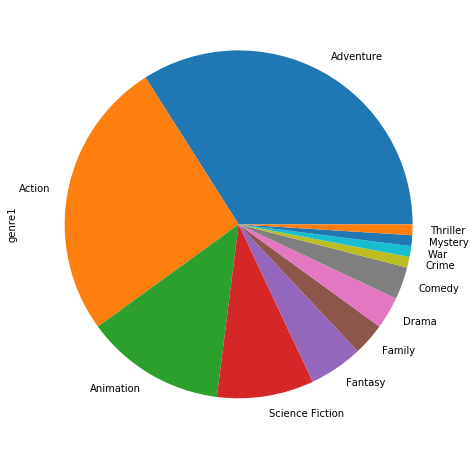

```python
# also view with a pie chart
df_top_100_movies['genre1'].value_counts().plot(kind='pie', figsize=(8,8))
```

-> Among the top 100 movies according to revenue, the following 5 genres appear the most: Adventure, Action, Animation, Science Fiction and Fantasy. Looking at the pie chart it looks like the top 3 genres Adventure, Action and Animation make almost 75% of the topp genres among the top 100 movies.

Question 2: Which genres have been the most popular (highest number of movies) during the years?

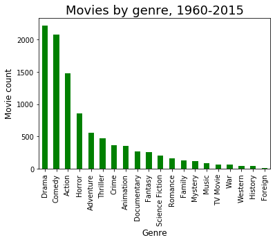

```python
#Overview of genres over time:
df['genre1'].value_counts().plot(kind='bar', color='g');
plt.title('Movies by genre, 1960-2015', size=18)
plt.xlabel('Genre', size=12)
plt.ylabel('Movie count', size=12);
```

```python
genres_per_decades = df.groupby(['decades'])['genre1'].value_counts()
```

```python
#The list above is too long, I will look at top 3 genres per decade:
genres_per_decades.groupby(level=0).nlargest(3).reset_index(level=0, drop=True)
```

```
decades  genre1
60s      Drama      75
         Comedy     68
         Action     56
70s      Drama     115
         Action     98
         Comedy     77
80s      Comedy    260
         Drama     194
         Action    178
90s      Comedy    437
         Drama     417
         Action    317
2000s    Comedy    805
         Drama     791
         Action    502
2010s    Drama     626
         Comedy    430
         Action    320
Name: genre1, dtype: int64
```

# Conclusions

Regarding the actors and genres a dataset of the top 100 movies according to revenue has been analysed. -> Some actors show up more frequently in successful movies than others: Sam Worthington, Harrison Ford, Kate Winslet, Robert Downey Jr. and Chris Pratt are the main actors in the top 5 movies accroding to revenue; -> Among the top 100 movies according to revenue, the following 5 actors appear the most: Daniel Radcliffe, Kristen Stewart, Jennifer Lawrence, Johnny Depp and Robert Downey Jr.; Among the top 100 movies according to revenue, the following 5 genres appear the most: -> Adventure, Action, Animation, Science Fiction and Fantasy.